# scipub vignette

David Pagliaccio

2021-03-17

The scipub package contains functions for summarizing data for scientific publication. This includes making a “Table 1” to summarize demographics across groups, correlation tables with significance indicated by stars, and extracting formatted statistical summarizes from simple tests for in-text notation. The package also includes functions for Winsorizing data based on a Z-statistic cutoff.  
The sample dataset of demographic and clinical data from 5,000 children is used for examples.

We’ll start by loading scipub:

```r
library(scipub)
data(psydat)
```

## `apastat`

The `apastat` function summarizes simple statistical tests to include in the text of an article, typically in a parenthetical. This is built for t-tests, correlations, ANOVA, and regression. Regressions can be summarized by their overall model fit or the parameter estimates for one predictor variable. Effect sizes are calculated where possible (default: `es=TRUE`). For example:

There is a significant positive correlation between age and height. 95% confidence intervals are requested.

```r
apastat(stats::cor.test(psydat$Age, psydat$Height), ci = TRUE)
```

```
#> r=.41, t(4991)=32.06, 95% CI=[.39,.44], p<.001
```

There is no significant sex difference in height in the sample.

```r
apastat(stats::t.test(Height ~ Sex, data = psydat))
```

```
#> t(4855.74)=0.83, p=.41, d=0.02
```

A linear regression model predicting height was highly significant, with the predictors (age and sex) accounting for about 17% of the variance in height.

```r
apastat(stats::lm(data = psydat, Height ~ Age + Sex))
```

```
#> N=4991, F(2,4988)=517.49, R2=.17, adj. R2=.17, p<.001
```

In this linear regression model, age was a highly significant predictor of height, controlling for sex.

```r
apastat(stats::lm(data = psydat, Height ~ Age + Sex), var = "Age")
```

```
#> N=4991, b=0.18, t(4988)=32.16, p<.001
```

## `correltable`

The `correltable` function creates a summary correlation table with asterisks to indicate significance. Variables can be renamed as part of the function call. The full matrix or upper/lower triangle can be selected for output. For the selected triangle, the empty row/column can be kept or deleted as needed. The caption provides information on the statistics included, any missing data, and the * indications. For example:

The lower triangle of inter-correlation among the age, height, and iq variables are shown.

```r
correltable(data = psydat, vars = c("Age", "Height", "iq"),tri="lower",html=TRUE)
```

|  | Age | Height | iq |
| --- | --- | --- | --- |
| Age |  |  |  |
| Height | .41*** |  |  |
| iq | .09*** | .04* |  |
| Note. This table presents Pearson correlation coefficients with pairwise deletion. N=7 missing Height. N=179 missing iq. * p<.05, ** p<.01, *** p<.001 |  |  |  |

These same variables can be relabeled in the output and, for conciseness, the columns can be indicated by corresponding number rather than variable name.

```r
correltable(data = psydat, vars = c("Age", "Height", "iq"), var_names = c("Age (months)", "Height (inches)", "IQ"), tri = "upper", colnum = TRUE,html=TRUE)
```

1

2

3

1. Age (months)

.41***

.09***

2. Height (inches)

.04*

3. IQ

Note. This table presents Pearson correlation coefficients with pairwise deletion. N=7 missing Height (inches). N=179 missing IQ. * p<.05, ** p<.01, *** p<.001

This can also be done with Spearman correlation. As well as using only complete data (list-wise deletion). And, the empty row/column can be removed if desired.

```r
correltable(data = psydat, vars = c("Age", "Height", "iq"), var_names = c("Age (months)", "Height (inches)", "IQ"), tri = "upper", method = "spearman", use = "complete", cutempty = TRUE, colnum = TRUE,html=TRUE)
```

2

3

1. Age (months)

.43***

.08***

2. Height (inches)

.04*

Note. This table presents Spearman correlation coefficients with list-wise deletion (N=4816, missing 184 cases) * p<.05, ** p<.01, *** p<.001

The inter-correlation between two sets of variables can also be shown.

```r
correltable(data = psydat, vars = c("Age", "Height", "iq"), var_names = c("Age (months)", "Height (inches)", "IQ"), vars2 = c("depressT", "anxT"), var_names2 = c("Depression T", "Anxiety T"),html=TRUE)
```

[output not shown]

The simplest call just correlates all variables in a dataset. Any non-numeric variables will be tested by t-test, chi-squared, or ANOVA as appropriate.

```r
correltable(data = psydat, html=TRUE)
```

[output not shown]

## `partial_correltable`

The `partial_correltable` function provides similar functionality to `correltable` but allows for covariates to be partialled out of all correlations. This function will allow for binary/factor covariates to be partialled out but only numeric variables can be correlated. This involves residualizing all `vars` by all `partialvars` via linear regression (`lm`). For example:

The lower triangle of partial correlations among the age, height, and iq variables are shown, residualizing for sex and income as factor variables.

```r
partial_correltable(data = psydat, vars = c("Age", "Height", "iq"), partialvars = c("Sex", "Income"), tri = "lower", html = TRUE)
```

[output not shown]

```r
partial_correltable(data = psydat, vars = c("Age", "Height", "iq"), var_names = c("Age (months)", "Height (inches)", "IQ"), partialvars = c("Sex", "Income"),tri = "upper", colnum = TRUE, html = TRUE)
```

1

2

3

1. Age

.42***

.09***

2. Height

.05***

3. iq

Note. This table presents Pearson partial correlation coefficients controlling for Sex, Income with pairwise deletion. N=5 missing Height. N=165 missing iq. N=406 excluded for missing covariates to be partialled out. * p<.05, ** p<.01, *** p<.001

This can also be done with Spearman correlation. As well as using only complete data (list-wise deletion). And, the empty row/column can be removed if desired.

```r
partial_correltable(data = psydat, vars = c("Age", "Height", "iq"), var_names = c("Age (months)", "Height (inches)", "IQ"), partialvars = c("Sex", "Income"),tri = "upper", method = "spearman", use = "complete", cutempty = TRUE, colnum = TRUE, html = TRUE)
```

2

3

1. Age

.43***

.07***

2. Height

.05***

Note. This table presents Spearman partial correlation coefficients controlling for Sex, Income with list-wise deletion (N=4424, missing 576 cases) * p<.05, ** p<.01, *** p<.001

## `FullTable1`

A “Table 1” can be created to summarize data, i.e. the typical first table in a paper that describes the sample characteristics. This can display information for a single group for the declared variables .

```r
FullTable1(data = psydat, vars = c("Age", "Sex","Height", "depressT"),  html=TRUE)
```

| Variable | Sample (N=5000) |
| --- | --- |
| Age | 120.86 (7.59) |
| Sex (M) | 2632 (52.68%) |
| Height | 57.3 (3.37) |
| depressT | 55.51 (5.69) |
| Note. N=4 missing Sex. N=7 missing Height. N=8 missing depressT. |  |

Or commonly this can be shown for two groups if interest including the tests of group difference for all variables.

```r
FullTable1(data = psydat, vars = c("Age", "Height", "depressT"), strata = "Sex", html=TRUE)
```

| Variable | F (N=2364) | M (N=2632) | Stat | p | sig | es |
| --- | --- | --- | --- | --- | --- | --- |
| Age | 120.65 (7.5) | 121.05 (7.66) | 1.86 | .06 |  | 0.05 |
| Height | 57.34 (3.48) | 57.27 (3.28) | -0.83 | .41 |  | -0.02 |
| depressT | 55.1 (5.27) | 55.88 (6.01) | 4.87 | <.001 | *** | 0.14 |
| Note. N=4 excluded for missing group variable. N=5 missing Height. N=4 missing depressT. * p<.05, ** p<.01, *** p<.001 |  |  |  |  |  |  |

This can also be created for more than two groups. As with `correltable` variables can be renamed in the call. Also the significance stars can be moved to the statistic column or variable name (or removed). The p-value column can be removed as well (same for the effect size column, but why would you want to remove that?).

```r
FullTable1(data = psydat, vars = c("Age", "Sex","Height", "depressT"), var_names = c("Age (months)", "Sex","Height (inches)", "Depression T"), strata = "Income", stars = "stat",p_col = FALSE, html=TRUE)
```

| Variable | [<50K] (N=1331) | [>=100K] (N=1957) | [>=50K&<100K] (N=1308) | Stat | es |
| --- | --- | --- | --- | --- | --- |
| Age (months) | 120.61 (7.53) | 121.23 (7.6) | 120.55 (7.56) | F=4.17 * | η2=0.00 |
| Sex (M) | 690 (51.88%) | 1034 (52.86%) | 700 (53.52%) | χ2=0.72 | V=0.01 |
| Height (inches) | 57.42 (3.49) | 57.29 (3.25) | 57.23 (3.25) | F=1.15 | η2=0.00 |
| Depression T | 56.4 (6.56) | 54.83 (4.9) | 55.63 (5.72) | F=31.18 *** | η2=0.01 |
| Note. N=404 excluded for missing group variable. N=2 missing Sex. N=5 missing Height (inches). N=4 missing Depression T. * p<.05, ** p<.01, *** p<.001 |  |  |  |  |  |

All variables will be summarized if none are declared Shown with significance stars on variable names.

```r
FullTable1(data = psydat, strata = "Sex",stars = "name",p_col = FALSE, html=TRUE)
```

| Variable | F (N=2364) | M (N=2632) | Stat | es |
| --- | --- | --- | --- | --- |
| Age | 120.65 (7.5) | 121.05 (7.66) | t=1.86 | d=0.05 |
| Income | - | - | χ2=0.72 | V=0.01 |
| [<50K] NA | 640 (29.49%) | 690 (28.47%) | - | - |
| [>=100K] NA | 922 (42.49%) | 1034 (42.66%) | - | - |
| [>=50K&<100K] NA | 608 (28.02%) | 700 (28.88%) | - | - |
| Height | 57.34 (3.48) | 57.27 (3.28) | t=-0.83 | d=-0.02 |
| iq | 103.04 (18.04) | 102.39 (18.01) | t=-1.25 | d=-0.04 |
| depressT *** | 55.1 (5.27) | 55.88 (6.01) | t=4.87 | d=0.14 |
| anxT *** | 55.06 (5.96) | 56.08 (6.53) | t=5.76 | d=0.16 |
| Note. N=4 excluded for missing group variable. N=402 missing Income. N=5 missing Height. N=177 missing iq. N=4 missing depressT. N=4 missing anxT. * p<.05, ** p<.01, *** p<.001 |  |  |  |  |

You can also replace the caption with your own input and re-output to HTML.

```r
tmp <- FullTable1(data = psydat,
   vars = c("Age", "Height", "depressT"), strata = "Sex")
   tmp$caption <- "Write your own caption"
   print(htmlTable::htmlTable(tmp$table, useViewer=T, rnames=F,caption=tmp$caption, pos.caption="bottom"))
```

| Variable | F (N=2364) | M (N=2632) | Stat | p | sig | es |
| --- | --- | --- | --- | --- | --- | --- |
| Age | 120.65 (7.5) | 121.05 (7.66) | 1.86 | .06 |  | 0.05 |
| Height | 57.34 (3.48) | 57.27 (3.28) | -0.83 | .41 |  | -0.02 |
| depressT | 55.1 (5.27) | 55.88 (6.01) | 4.87 | <.001 | *** | 0.14 |
| Write your own caption |  |  |  |  |  |  |

## Winsorizing

The `winsorZ` function allows for Winsorizing outliers based on a Z-score cutoff, i.e. replacing extreme values with the next most extreme outlier value. This is an alternative to other function, e.g. `DescTools::Winsorize` which identifies outlier based on quantile limits. The `winsorZ` function can be used in combination with the `winsorZ_find` function, which identifies the outlier values (1=outlier, 0=non-outlier).

For example, in the example data, psydat$iq has 17 outliers that exceed a default |Z|>3 limit test. Here, we create a temporary data frame with the original iq scores, the Z-score winsorized iq values, and an indication of which scores were winsorized. We can see the change in mix/max iq values in the summary and the winsorized outliers are shown in blue in the plot.

```r
temp <- data.frame(iq=psydat$iq, iq_winsor=winsorZ(psydat$iq), iq_outlier = winsorZ_find(psydat$iq))
summary(temp)
```

```
   iq           iq_winsor      iq_outlier
```

Min. : 34.86 Min. : 48.74 0 :4804  
1st Qu.: 90.58 1st Qu.: 90.58 1 : 17  
Median :101.96 Median :101.96 NA’s: 179  
Mean :102.70 Mean :102.64  
3rd Qu.:113.86 3rd Qu.:113.86  
Max. :222.99 Max. :156.12  
NA’s :179 NA’s :179

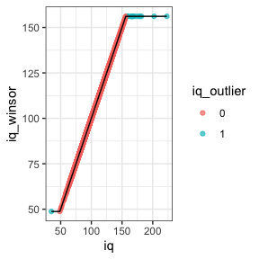

```r
ggplot(temp[!is.na(temp$iq),], aes(x=iq, y=iq_winsor)) + geom_point(aes(color=iq_outlier),alpha=.7) + geom_line() + theme_bw()
```

## Group Difference Plot

The `gg_groupplot` function creates can be used to create group difference plots for scientific publication. This is intended to summarize a continuous outcome (`y`) based on a factor (‘x’) from an input dataset (`data`). The plot will include standard ggplot2::geom_boxplot indicating 25th, median, and 75th percentile for the box and 1.5 * IQR for the whiskers. Outliers are not highlighted. Raw data is displayed with standard ggplot2::geom_point and lateral but not vertical jittering. Histograms are shown with gghalves::geom_half_violin to the right of each boxplot.If meanline = = TRUE (default), gray dots will indicate the mean for each variable (vs. median in boxplot) connected by a gray line. This function will drop any NA values.

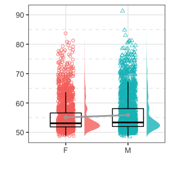

```r
gg_groupplot(data=psydat, x=Sex, y=depressT)
```

This can be combined with other `ggplot` graphics functions, e.g. facetting.

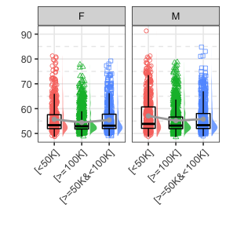

```r
gg_groupplot(data=psydat, x=Income, y=depressT) + facet_wrap(~Sex) + theme(axis.text.x = element_text(angle = 45, vjust = 1, hjust=1))
```